# 2020 Election Analysis 131 project

**8. Color the map of the state of California by the winning candidate for each county. Note that some county have not finished counting the votes, and thus do not have a winner. Leave these counties uncolored.**

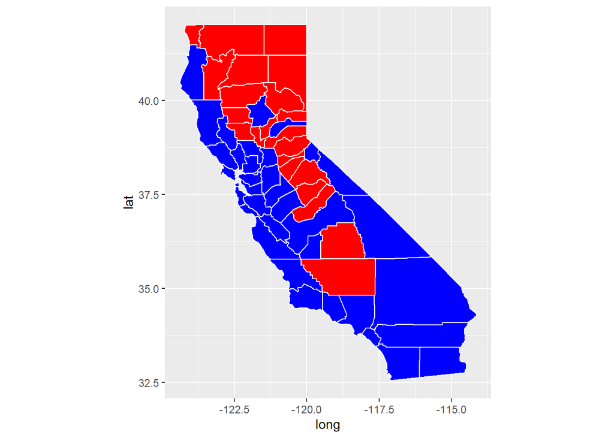

**9. (Open-ended) Create a visualization of your choice using census data. Many exit polls noted that demographics played a big role in the election. Use this Washington Post article and this R graph gallery for ideas and inspiration.**

We want to compare the distribution of some demographics for Biden county and Trump county:

We could use ridge line plot to compare two distributions.

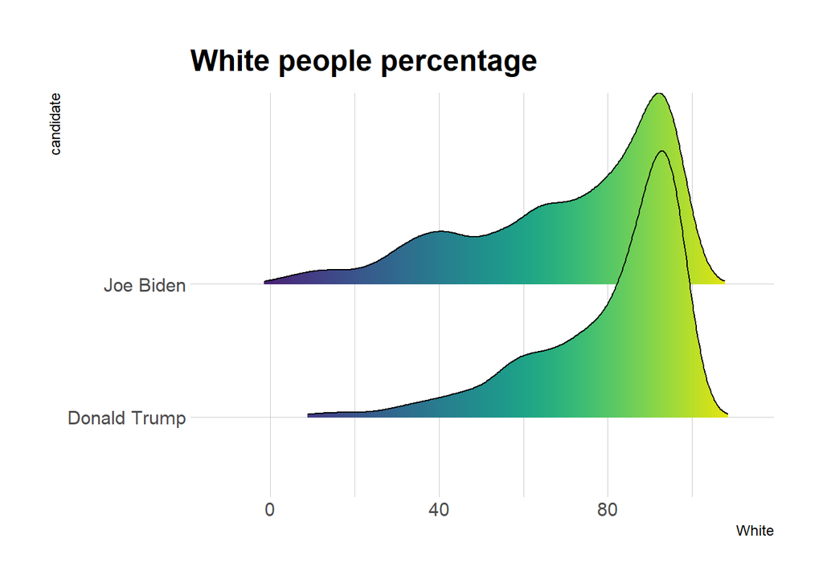

In the distribution of white people percentage in county who support Biden, there are more counties lies on the left side compared to Trump county distribution. So there are more Minority communities supporting Biden.

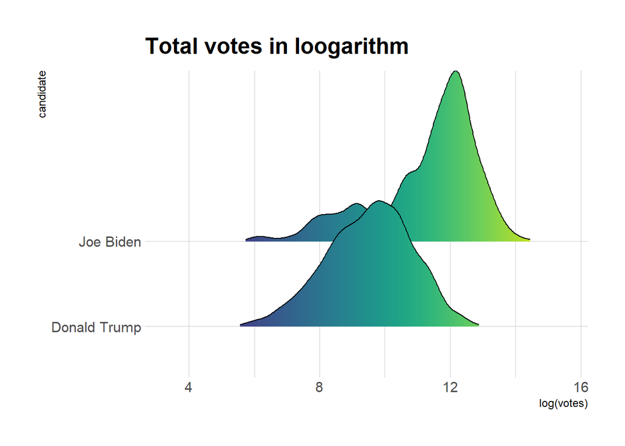

Apparently, the distribution of Trump and Biden county in log(votes) differs a lot. Biden counties consist of more county of more voters, which refer to big cities and downtown districts. Trump county, on the other hand, are mainly consist of smaller towns or rural parts.

**10. The census data contains county-level census information. In this problem, we clean and aggregate the information as follows.**

- Clean county-level census data census.clean: start with census, filter out any rows with missing values, convert {Men, Employed, VotingAgeCitizen} attributes to percentages, compute Minority attribute by combining {Hispanic, Black, Native, Asian, Pacific}, remove these variables after creating Minority, remove {IncomeErr, IncomePerCap, IncomePerCapErr, Walk, PublicWork, Construction}. Many columns are perfectly colineared, in which case one column should be deleted.
- Print the first 5 rows of census.clean:

```
## # A tibble: 5 x 26
##   CountyId State County TotalPop   Men White VotingAgeCitizen Income Poverty
##      <dbl> <chr> <chr>     <dbl> <dbl> <dbl>            <dbl>  <dbl>   <dbl>
## 1     1001 Alab~ Autau~    55036  48.9  75.4             74.5  55317    13.7
## 2     1003 Alab~ Baldw~   203360  48.9  83.1             76.4  52562    11.8
## 3     1005 Alab~ Barbo~    26201  53.3  45.7             77.4  33368    27.2
## 4     1007 Alab~ Bibb ~    22580  54.3  74.6             78.2  43404    15.2
## 5     1009 Alab~ Bloun~    57667  49.4  87.4             73.7  47412    15.6
## # ... with 17 more variables: ChildPoverty <dbl>, Professional <dbl>,
## #   Service <dbl>, Office <dbl>, Production <dbl>, Drive <dbl>, Carpool <dbl>,
## #   Transit <dbl>, OtherTransp <dbl>, WorkAtHome <dbl>, MeanCommute <dbl>,
## #   Employed <dbl>, PrivateWork <dbl>, SelfEmployed <dbl>, FamilyWork <dbl>,
## #   Unemployment <dbl>, Minority <dbl>
```

## **Dimensionality reduction**

**11. Run PCA for the cleaned county level census data (with State and County excluded).** Save the first two principle components PC1 and PC2 into a two-column data frame, call it pc.county. Discuss whether you chose to center and scale the features before running PCA and the reasons for your choice.

Center and scale are needed on the data before running PCA, because different columns has different mean and variation, some column such as population is very dispersed.

What are the three features with the largest absolute values of the first principal component?

Top 3 features of PC1

|  | PC1 | PC2 | features |
| --- | --- | --- | --- |
| Poverty | -0.3817489 | -0.0904984 | Poverty |
| ChildPoverty | -0.3810706 | -0.0508980 | ChildPoverty |
| Employed | 0.3510978 | 0.0374538 | Employed |

The features Employed has a negative sign to the features Poverty and ChildPoverty, thus have a negative correlation.

**12. Determine the number of minimum number of PCs needed to capture 90% of the variance for the analysis.** Plot proportion of variance explained (PVE) and cumulative PVE.

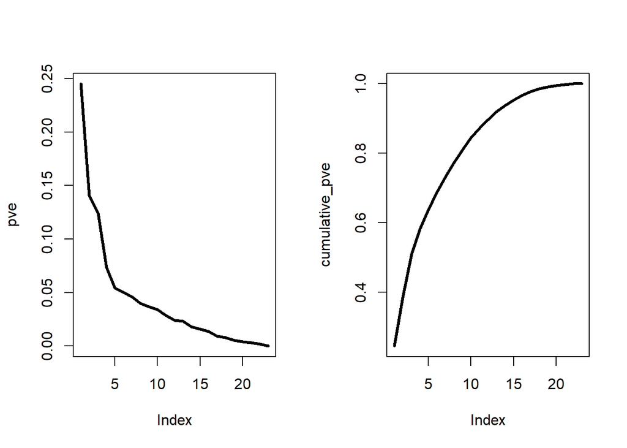

13 PCs are needed to capture 90% of the variance of the data.

## *Clustering*

**13. With census.clean (with State and County excluded), perform hierarchical clustering with complete linkage.** Cut the tree to partition the observations into 10 clusters.

cluster results

| 1 | 2 | 3 | 4 | 5 | 6 | 7 | 8 | 9 | 10 |
| --- | --- | --- | --- | --- | --- | --- | --- | --- | --- |
| 3111 | 69 | 2 | 9 | 12 | 1 | 2 | 5 | 7 | 1 |

Re-run the hierarchical clustering algorithm using the first 2 principal components from pc.county as inputs instead of the original features.

cluster results on pca

| 1 | 2 | 3 | 4 | 5 | 6 | 7 | 8 | 9 | 10 |
| --- | --- | --- | --- | --- | --- | --- | --- | --- | --- |
| 1433 | 924 | 94 | 601 | 15 | 90 | 1 | 21 | 8 | 32 |

Compare the results and comment on your observations. For both approaches investigate the cluster that contains Santa Barbara County. Which approach seemed to put Santa Barbara County in a more appropriate clusters? Comment on what you observe and discuss possible explanations for these observations.

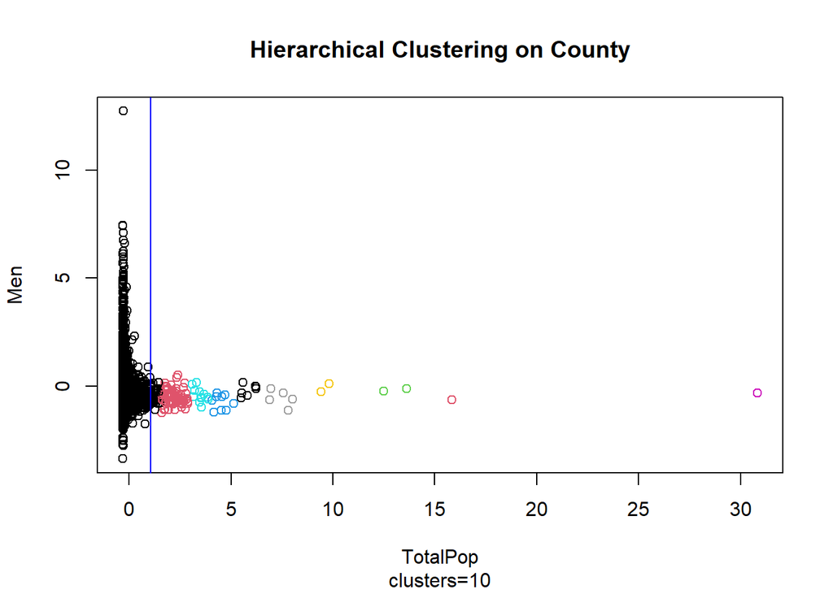

```
## [1] 1
```

Santa Barbara (blue line) is in the first cluster, with 3111 observations.

When the cluster is used on the first 2 principle components:

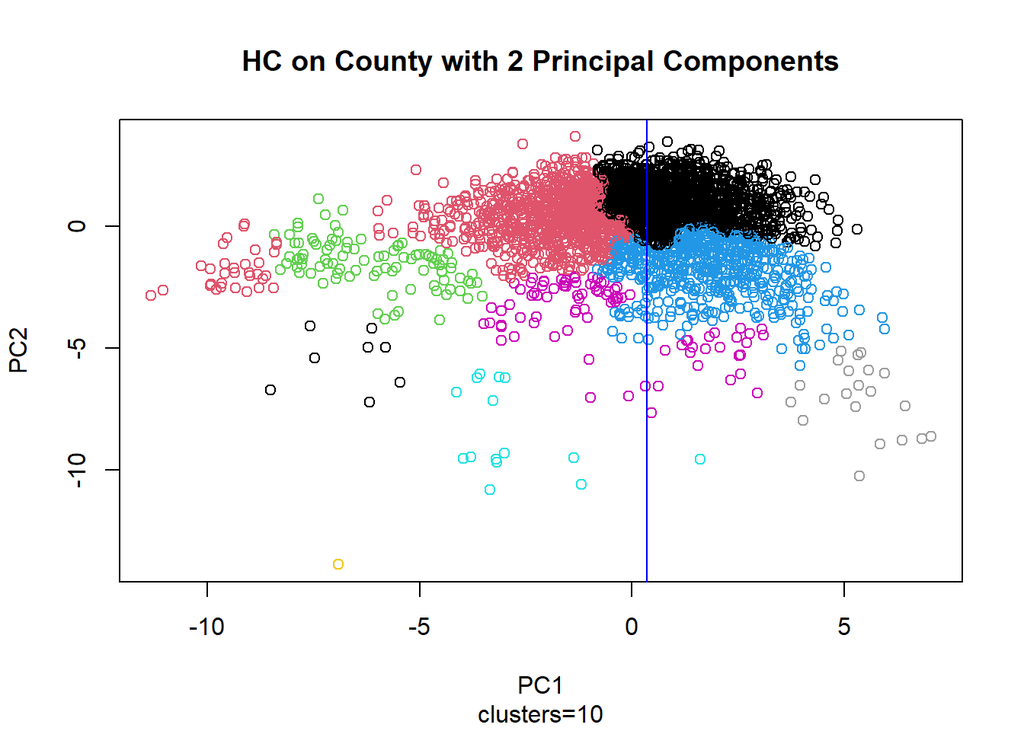

```
## [1] 4
```

It is in the 4th cluster with only 601 counties. The cluster method using the PCA is better.

## *Classification*

We start considering supervised learning tasks now. The most interesting/important question to ask is: can we use census information in a county to predict the winner in that county?

In order to build classification models, we first need to combine county.winner and census.clean data. This seemingly straightforward task is harder than it sounds. For simplicity, the following code makes necessary changes to merge them into election.cl for classification.

**14. Understand the code above. Why do we need to exclude the predictor party from election.cl?**

The party predictor is exactly the same with the candidate in information.

Using the following code, partition data into 80% training and 20% testing:

```r
set.seed(10)
n <- nrow(election.cl)
idx.tr <- sample.int(n, 0.8*n)
election.tr <- election.cl[idx.tr, ]
election.te <- election.cl[-idx.tr, ]
```

Use the following code to define 10 cross-validation folds:

```r
set.seed(20)
nfold <- 10
folds <- sample(cut(1:nrow(election.tr), breaks=nfold, labels=FALSE))
```

Using the following error rate function. And the object records is used to record the classification performance of each method in the subsequent problems.

```r
calc_error_rate = function(predicted.value, true.value){
return(mean(true.value!=predicted.value))
}
records = matrix(NA, nrow=6, ncol=2)
colnames(records) = c("train.error","test.error")
rownames(records) = c("tree","logistic","lasso","knn","lda","qda")
```

## *Decision tree*

15. Decision tree: train a decision tree by cv.tree(). Prune tree to minimize misclassification error. Be sure to use the folds from above for cross-validation.

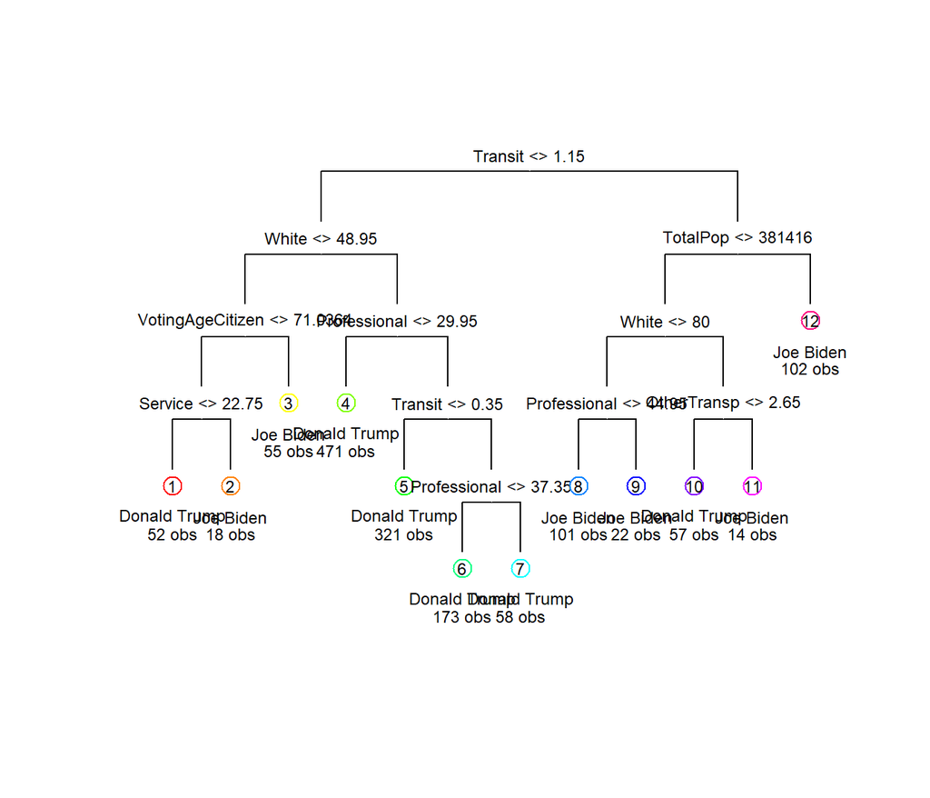

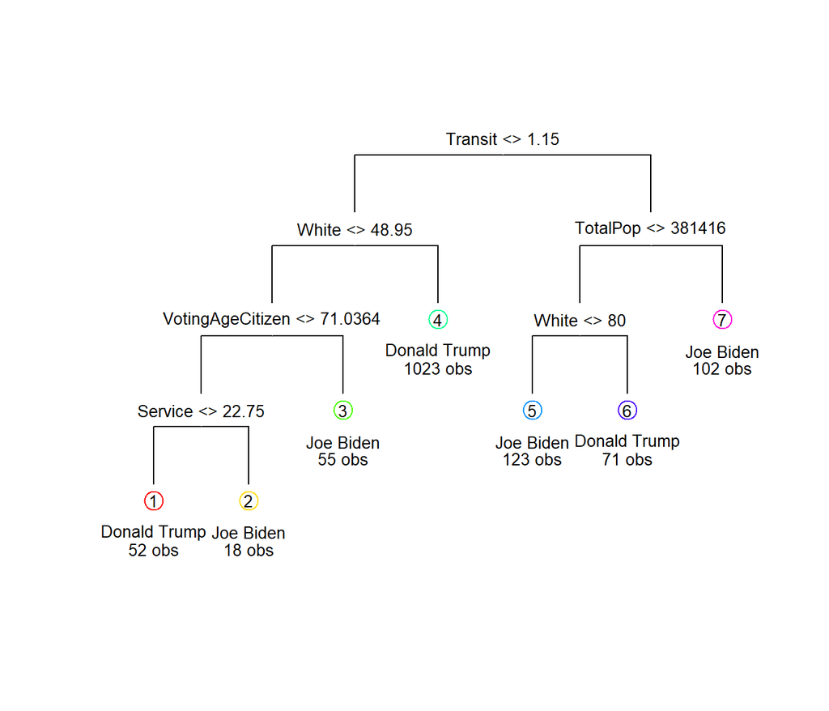

```
##          train.error test.error
## tree      0.08933518  0.1301939
## logistic          NA         NA
## lasso             NA         NA
## knn               NA         NA
## lda               NA         NA
## qda               NA         NA
```

We observe that transit and population, white plays an important role in the decision tree. We interpret it as:

The bigger the city is (higher population and larger transit distance), the more favorable on Biden.

The less white people percentage is (more Minority people), the more favorable on Biden.

## *Logistic regression*

**16. Run a logistic regression to predict the winning candidate in each county.** Save training and test errors to records variable.

```
##
## Call:
## glm(formula = candidate ~ ., family = binomial, data = election.tr)
##
## Deviance Residuals:
##     Min       1Q   Median       3Q      Max
## -3.8427  -0.2544  -0.0993  -0.0222   3.3552
##
## Coefficients:
##                    Estimate Std. Error z value Pr(>|z|)
## (Intercept)      -2.027e+01  1.189e+01  -1.705  0.08822 .
## TotalPop          1.891e-06  7.630e-07   2.479  0.01319 *
## Men              -3.220e-03  6.133e-02  -0.053  0.95812
## White            -2.038e-01  8.562e-02  -2.380  0.01730 *
## VotingAgeCitizen  1.752e-01  3.130e-02   5.598 2.17e-08 ***
## Income           -1.335e-05  2.002e-05  -0.667  0.50492
## Poverty           1.683e-02  5.159e-02   0.326  0.74421
## ChildPoverty     -4.406e-04  3.200e-02  -0.014  0.98901
## Professional      3.130e-01  5.176e-02   6.047 1.48e-09 ***
## Service           3.265e-01  6.276e-02   5.202 1.97e-07 ***
## Office            1.587e-01  6.313e-02   2.514  0.01194 *
## Production        2.291e-01  5.368e-02   4.267 1.98e-05 ***
## Drive            -2.175e-01  5.685e-02  -3.827  0.00013 ***
## Carpool          -2.247e-01  7.541e-02  -2.980  0.00288 **
## Transit           5.601e-02  1.151e-01   0.487  0.62660
## OtherTransp       1.305e-01  1.167e-01   1.118  0.26370
## WorkAtHome       -1.312e-01  8.802e-02  -1.491  0.13595
## MeanCommute       3.580e-02  3.200e-02   1.119  0.26330
## Employed          2.442e-01  4.228e-02   5.776 7.65e-09 ***
## PrivateWork       7.147e-02  2.819e-02   2.535  0.01124 *
## SelfEmployed      1.955e-02  5.889e-02   0.332  0.73986
## FamilyWork       -3.708e-01  3.352e-01  -1.106  0.26854
## Unemployment      1.475e-01  5.167e-02   2.855  0.00431 **
## Minority         -5.898e-02  8.261e-02  -0.714  0.47525
## ---
## Signif. codes:  0 '***' 0.001 '**' 0.01 '*' 0.05 '.' 0.1 ' ' 1
##
## (Dispersion parameter for binomial family taken to be 1)
##
##     Null deviance: 1483.67  on 1443  degrees of freedom
## Residual deviance:  523.43  on 1420  degrees of freedom
## AIC: 571.43
##
## Number of Fisher Scoring iterations: 7
```

In the logistic regression result, the significant variables include TotalPop, White, VotingAgeCitizen, Professional, Service, Office, Production, Drive, Carpool, Employed, Private Work and Unemployment.

While White, population, VotingAgeCitizen and service is significant in regression, the variable transit is not. So there is a little discrepency between logistic regression and decision tree.

Interpretation of the variable slope:

The coefficient for VotingAgeCitizen= 0.1752 which is interpreted as the expected change in log odds for a one-unit increase in the VotingAgeCitizen. The odds ratio can be calculated by exponentiating this value to get 1.191484 which means we expect to see about 19.15% increase in the odds of favoring Biden.

The coefficient for White= -0.2038 which is interpreted as the expected change in log odds for a one-unit increase in the White. The odds ratio can be calculated by exponentiating this value to get 0.8156255 which means we expect to see about 18.43% decrease in the odds of favoring Biden.

**17. You may notice that you get a warning glm.fit: fitted probabilities numerically 0 or 1 occurred.** As we discussed in class, this is an indication that we have perfect separation (some linear combination of variables perfectly predicts the winner). This is usually a sign that we are overfitting. One way to control overfitting in logistic regression is through regularization.

Use the cv.glmnet function from the glmnet library to run a 10-fold cross validation and select the best regularization parameter for the logistic regression with LASSO penalty. Set lambda = seq(1, 50) * 1e-4 in cv.glmnet() function to set pre-defined candidate values for the tuning parameter $\lambda$. What is the optimal value of $\lambda$ in cross validation?

```
##
## Call:  cv.glmnet(x = as.matrix(train.X), y = droplevels(train.Y$candidate),      lambda = seq(1, 50) * 1e-04, foldid = folds, family = "binomial",      alpha = 1)
##
## Measure: Binomial Deviance
##
##     Lambda Measure      SE Nonzero
## min 0.0013  0.3993 0.02989      20
## 1se 0.0050  0.4166 0.02448      18
```

The optimal value of $\lambda$ is 0.0013.

```
##      (Intercept)         TotalPop              Men            White
##    -2.324254e+01     1.961438e-06    -1.864213e-02    -1.288823e-01
## VotingAgeCitizen           Income          Poverty     ChildPoverty
##     1.659910e-01     0.000000e+00     2.456150e-02     0.000000e+00
##     Professional          Service           Office       Production
##     2.459491e-01     2.562674e-01     1.091326e-01     1.616569e-01
##            Drive          Carpool          Transit      OtherTransp
##    -1.573310e-01    -1.512788e-01     8.998134e-02     1.473312e-01
##       WorkAtHome      MeanCommute         Employed      PrivateWork
##    -6.000473e-02     8.272084e-03     2.096446e-01     5.740849e-02
##     SelfEmployed       FamilyWork     Unemployment         Minority
##    -1.002785e-02    -3.230281e-01     1.387075e-01     0.000000e+00
```

ChildPoverty, Minority and Income are set 0. The difference between logistic fit is:

```
##      (Intercept)         TotalPop              Men            White
##    -2.974337e+00     7.021907e-08    -1.542182e-02     7.492657e-02
## VotingAgeCitizen           Income          Poverty     ChildPoverty
##    -9.203889e-03     1.334970e-05     7.727145e-03     4.405959e-04
##     Professional          Service           Office       Production
##    -6.706318e-02    -7.021608e-02    -4.957551e-02    -6.741350e-02
##            Drive          Carpool          Transit      OtherTransp
##     6.021025e-02     7.344991e-02     3.396994e-02     1.686733e-02
##       WorkAtHome      MeanCommute         Employed      PrivateWork
##     7.123813e-02    -2.752763e-02    -3.455786e-02    -1.406562e-02
##     SelfEmployed       FamilyWork     Unemployment         Minority
##    -2.958020e-02     4.780016e-02    -8.787150e-03     5.898260e-02
```

**18. Compute ROC curves for the decision tree, logistic regression and LASSO logistic regression using predictions on the test data.** Display them on the same plot. Based on your classification results, discuss the pros and cons of the various methods. Are the different classifiers more appropriate for answering different kinds of questions about the election?

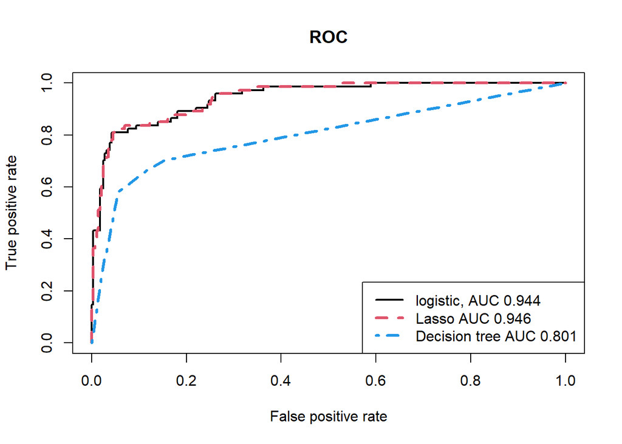

From the AUC perspective, the Lasso and logistic has similar performance and they are much better than the decision tree.

## *Taking it further*

**19. Explore additional classification methods.** Consider applying additional two classification methods from KNN, LDA, QDA, SVM, random forest, boosting, neural networks etc. (You may research and use methods beyond those covered in this course). How do these compare to the tree method, logistic regression, and the lasso logistic regression?

- KNN

10 fold Cross validation to decide the best K for the KNN method.

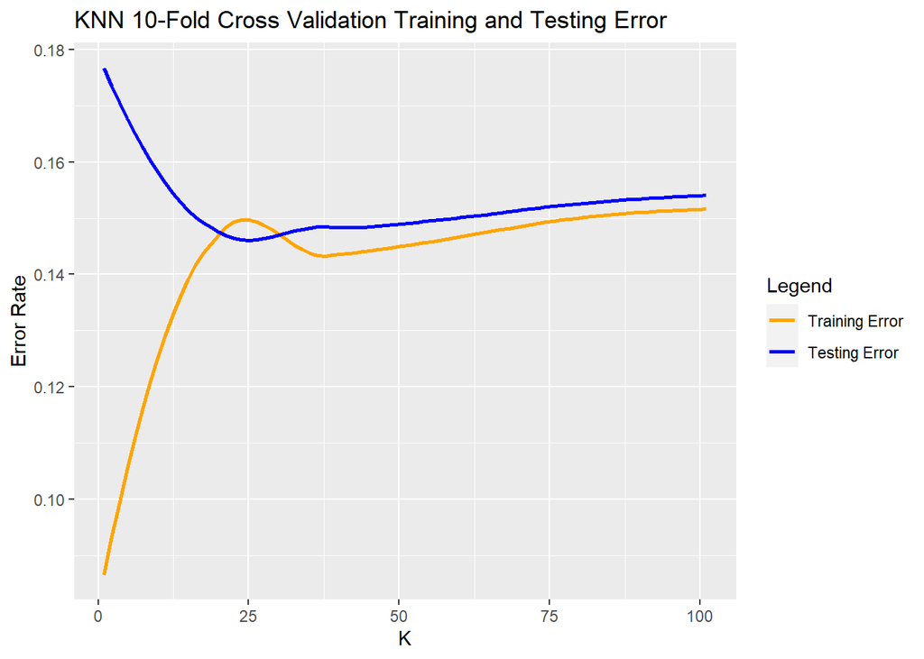

```
##          train.error test.error
## tree      0.08933518 0.13019391
## logistic  0.06717452 0.08310249
## lasso     0.07063712 0.08033241
## knn       0.14473684 0.18282548
## lda               NA         NA
## qda               NA         NA
```

- LDA

```
## Call:
## lda(candidate ~ ., data = election.tr)
##
## Prior probabilities of groups:
## Donald Trump    Joe Biden
##    0.7901662    0.2098338
##
## Group means:
##               TotalPop      Men    White VotingAgeCitizen   Income  Poverty
## Donald Trump  60122.74 50.06975 78.92577         74.93871 49178.66 15.78528
## Joe Biden    452372.61 49.29129 54.52640         72.23015 56793.19 17.48713
##              ChildPoverty Professional  Service   Office Production    Drive
## Donald Trump     21.92436     30.95337 17.97835 21.92165   15.87949 80.43006
## Joe Biden        23.35941     37.12046 19.36403 22.60000   11.88053 76.26502
##               Carpool   Transit OtherTransp WorkAtHome MeanCommute Employed
## Donald Trump 9.975372 0.5234005    1.430061   4.755478    23.21183 43.48248
## Joe Biden    9.505941 3.8052805    2.015842   4.803630    24.66436 45.78547
##              PrivateWork SelfEmployed FamilyWork Unemployment Minority
## Donald Trump    75.21867     7.956266  0.2943032     6.156705 19.13716
## Joe Biden       76.31881     5.961386  0.1815182     7.614851 42.81881
##
## Coefficients of linear discriminants:
##                            LD1
## TotalPop          4.754919e-07
## Men               1.996140e-03
## White            -6.103332e-02
## VotingAgeCitizen  5.171246e-02
## Income            9.746842e-06
## Poverty           7.183072e-02
## ChildPoverty     -2.032019e-02
## Professional      1.281583e-01
## Service           1.139078e-01
## Office            5.194220e-02
## Production        6.841514e-02
## Drive            -8.432929e-02
## Carpool          -6.699942e-02
## Transit          -9.044868e-02
## OtherTransp       1.942096e-02
## WorkAtHome       -4.772282e-02
## MeanCommute       2.856477e-02
## Employed          7.227185e-02
## PrivateWork       3.734237e-02
## SelfEmployed      6.875921e-04
## FamilyWork       -5.626700e-02
## Unemployment      5.602593e-02
## Minority         -9.816209e-03
```

- QDA

```
## Call:
## qda(candidate ~ ., data = election.tr)
##
## Prior probabilities of groups:
## Donald Trump    Joe Biden
##    0.7901662    0.2098338
##
## Group means:
##               TotalPop      Men    White VotingAgeCitizen   Income  Poverty
## Donald Trump  60122.74 50.06975 78.92577         74.93871 49178.66 15.78528
## Joe Biden    452372.61 49.29129 54.52640         72.23015 56793.19 17.48713
##              ChildPoverty Professional  Service   Office Production    Drive
## Donald Trump     21.92436     30.95337 17.97835 21.92165   15.87949 80.43006
## Joe Biden        23.35941     37.12046 19.36403 22.60000   11.88053 76.26502
##               Carpool   Transit OtherTransp WorkAtHome MeanCommute Employed
## Donald Trump 9.975372 0.5234005    1.430061   4.755478    23.21183 43.48248
## Joe Biden    9.505941 3.8052805    2.015842   4.803630    24.66436 45.78547
##              PrivateWork SelfEmployed FamilyWork Unemployment Minority
## Donald Trump    75.21867     7.956266  0.2943032     6.156705 19.13716
## Joe Biden       76.31881     5.961386  0.1815182     7.614851 42.81881
```

```
##          train.error test.error
## tree      0.08933518 0.13019391
## logistic  0.06717452 0.08310249
## lasso     0.07063712 0.08033241
## knn       0.14473684 0.18282548
## lda       0.07479224 0.31232687
## qda       0.09141274 0.32063712
```

**20. Tackle at least one more interesting question. Creative and thoughtful analysis will be rewarded!**

Instead of using the native attributes (the original features), we can use principal components to create new (and lower dimensional) set of features with which to train a classification model. This sometimes improves classification performance. Compare classifiers trained on the original features with those trained on PCA features.

```
## [1] 12
```

- Decision tree

```
##          train.error test.error
## tree      0.09487535  0.1578947
## logistic          NA         NA
## lasso             NA         NA
## knn               NA         NA
## lda               NA         NA
## qda               NA         NA
```

- Logistic

```
##
## Call:
## glm(formula = y ~ ., family = binomial, data = tr.pca)
##
## Deviance Residuals:
##     Min       1Q   Median       3Q      Max
## -4.7417  -0.3702  -0.1946  -0.0779   3.0935
##
## Coefficients:
##             Estimate Std. Error z value Pr(>|z|)
## (Intercept) -2.09280    0.13169 -15.892  < 2e-16 ***
## PC1          0.01142    0.04197   0.272  0.78556
## PC2         -1.90265    0.12087 -15.742  < 2e-16 ***
## PC3          0.14732    0.06487   2.271  0.02315 *
## PC4          0.69497    0.09065   7.666 1.77e-14 ***
## PC5          0.72191    0.13550   5.328 9.94e-08 ***
## PC6          0.52592    0.10882   4.833 1.35e-06 ***
## PC7          0.24528    0.08939   2.744  0.00607 **
## PC8          0.80836    0.12100   6.680 2.38e-11 ***
## PC9         -0.20151    0.13851  -1.455  0.14572
## PC10         0.62472    0.13497   4.629 3.68e-06 ***
## PC11         0.30324    0.16562   1.831  0.06711 .
## PC12        -0.13758    0.14993  -0.918  0.35879
## ---
## Signif. codes:  0 '***' 0.001 '**' 0.01 '*' 0.05 '.' 0.1 ' ' 1
##
## (Dispersion parameter for binomial family taken to be 1)
##
##     Null deviance: 1483.67  on 1443  degrees of freedom
## Residual deviance:  698.97  on 1431  degrees of freedom
## AIC: 724.97
##
## Number of Fisher Scoring iterations: 7
```

- LASSO
- KNN

10 fold Cross validation to decide the best K for the KNN method.

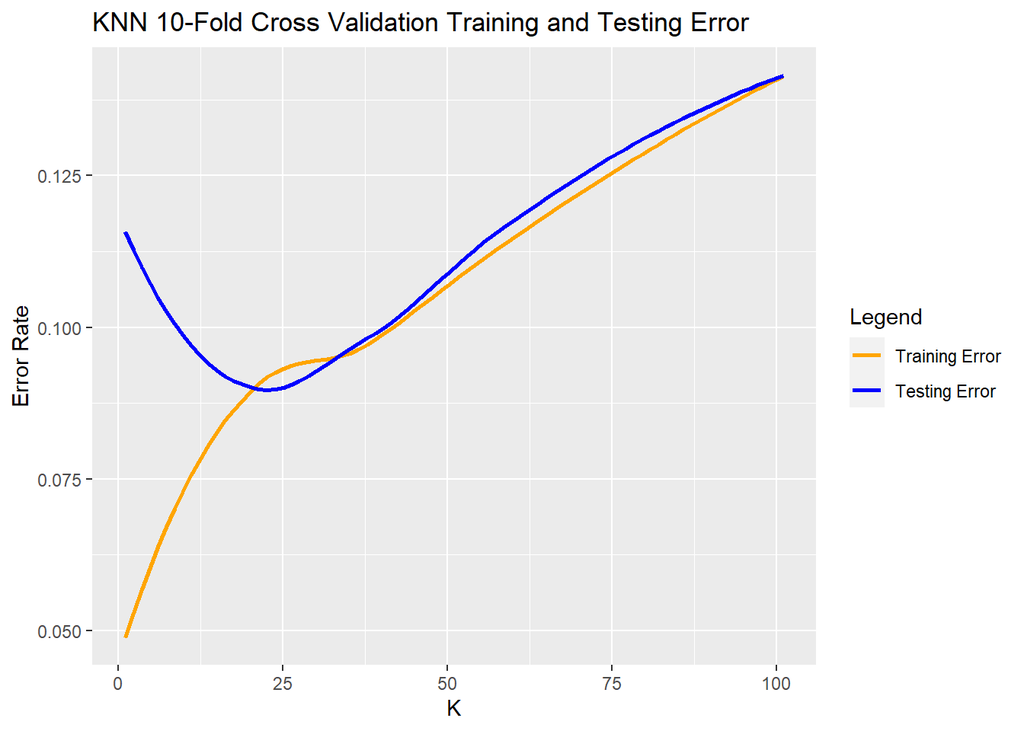

Unlike the original full data case, the train error and test error increase greatly when K become larger.

- LDA

```
## Call:
## lda(y ~ ., data = tr.pca)
##
## Prior probabilities of groups:
## Donald Trump    Joe Biden
##    0.7901662    0.2098338
##
## Group means:
##                      PC1        PC2         PC3         PC4         PC5
## Donald Trump -0.03210017  0.5739316 -0.03133074 -0.07764162  0.02246269
## Joe Biden     0.12087885 -2.1612407  0.11798144  0.29237324 -0.08458721
##                      PC6         PC7         PC8         PC9        PC10
## Donald Trump -0.03714447 -0.01564902 -0.03761421 -0.01271413 -0.01168134
## Joe Biden     0.13987404  0.05892916  0.14164296  0.04787731  0.04398815
##                     PC11        PC12
## Donald Trump -0.03434462 -0.02262952
## Joe Biden     0.12933073  0.08521546
##
## Coefficients of linear discriminants:
##              LD1
## PC1   0.02347576
## PC2  -0.69096672
## PC3   0.03902193
## PC4   0.19462352
## PC5  -0.06869558
## PC6   0.12648347
## PC7   0.05597450
## PC8   0.16171121
## PC9   0.05897518
## PC10  0.06084483
## PC11  0.19650311
## PC12  0.16542382
```

- QDA

```
## Call:
## qda(y ~ ., data = tr.pca)
##
## Prior probabilities of groups:
## Donald Trump    Joe Biden
##    0.7901662    0.2098338
##
## Group means:
##                      PC1        PC2         PC3         PC4         PC5
## Donald Trump -0.03210017  0.5739316 -0.03133074 -0.07764162  0.02246269
## Joe Biden     0.12087885 -2.1612407  0.11798144  0.29237324 -0.08458721
##                      PC6         PC7         PC8         PC9        PC10
## Donald Trump -0.03714447 -0.01564902 -0.03761421 -0.01271413 -0.01168134
## Joe Biden     0.13987404  0.05892916  0.14164296  0.04787731  0.04398815
##                     PC11        PC12
## Donald Trump -0.03434462 -0.02262952
## Joe Biden     0.12933073  0.08521546
```

```
##          train.error test.error
## tree      0.09487535  0.1578947
## logistic  0.09349030  0.1662050
## lasso     0.09279778  0.1551247
## knn       0.07271468  0.1828255
## lda       0.10734072  0.2880886
## qda       0.09833795  0.3067867
```

Compare with the original way error rate:

```
##           train.error  test.error
## tree      0.005540166  0.02770083
## logistic  0.026315789  0.08310249
## lasso     0.022160665  0.07479224
## knn      -0.072022161  0.00000000
## lda       0.032548476 -0.02423823
## qda       0.006925208 -0.01385042
```

**21. (Open ended) Interpret and discuss any overall insights gained in this analysis and possible explanations.**

It seems that except the knn, lda and qda method, all other three methods are actually become worse in performance.

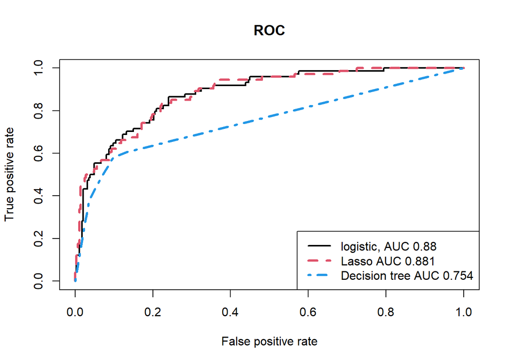

We also calculate the ROC curve of the PCA case, and the AUC all decrease from the original ones. Given that the knn, lda and qda methods are not so good compared to the first three methods, we may should not apply PCA and analysis on the PCA.

Another interesting issue is that, when we use KNN method on the PCA, the train error and test error increase significantly when the k parameter become larger. But on the original dataset, it is not.

## Visualize errors on the map using logisitic predictor

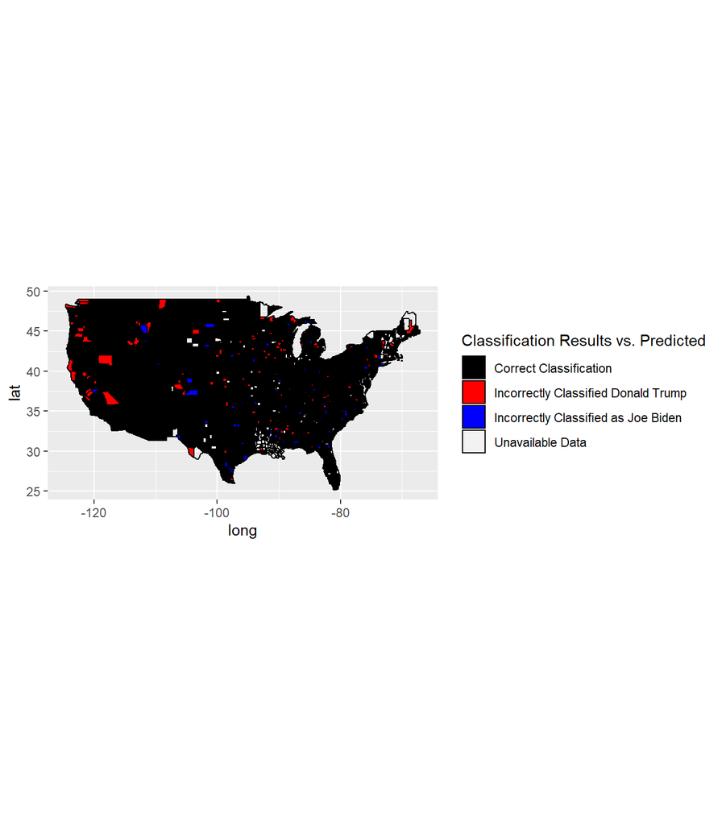

## Appendix: R code

```r
knitr::opts_chunk$set(echo=FALSE, message=FALSE, warning=FALSE)
library(knitr)
library(tidyverse)
library(ggmap)
library(maps)
library(Rtsne)
library(NbClust)
library(tree)
library(maptree)
library(ggplot2)
library(glmnet)
library(plotROC)
library(class)
library(randomForest)
library(reshape2)
library(ggridges)
library(ggplot2)
library(viridis)
library(hrbrthemes)
## read data and convert candidate names and party names from string to factor
election.raw <- read_csv("candidates_county.csv", col_names = TRUE) %>%
  mutate(candidate = as.factor(candidate), party = as.factor(party))

## remove the word "County" from the county names
words.to.remove = c("County")
remove.words <- function(str, words.to.remove){
  sapply(str, function(str){
    x <- unlist(strsplit(str, " "))
    x <- x[!x %in% words.to.remove]
    return(paste(x, collapse = " "))
  }, simplify = "array", USE.NAMES = FALSE)
}
election.raw$county <- remove.words(election.raw$county, words.to.remove)

## read census data
census <- read_csv("census_county.csv")
dim(election.raw)
sum(is.na(election.raw))
length(unique(election.raw$state))
dim(census)
sum(is.na(census))
length(unique(election.raw$county))
length(unique(census$County))
election.total = election.raw %>%
   group_by(candidate,party) %>%
   summarise(votes = sum(votes))
election.state = election.raw %>%
   group_by(state,candidate,party) %>%
   summarise(votes = sum(votes))
length(levels(election.state$candidate))
Candidate_Votes <-  election.total %>% select(candidate, votes)
Candidate_Votes <-
  Candidate_Votes[order(Candidate_Votes$votes),]


Candidate_Votes <- Candidate_Votes %>%
  mutate(percentage = votes/sum(Candidate_Votes$votes))

ggplot(Candidate_Votes, aes(reorder(candidate,percentage), percentage)) +
  geom_col(fill = c(rep("black", times = nrow(Candidate_Votes) - 2), "red", "blue"))+coord_flip()+ labs(title = "2020 U.S. Presidential Election Candidate Votes", x = "Candidate", y = "Share of Votes by Percentage") +
  geom_text(aes(label=votes), size = 3, nudge_y = 0.04, nudge_x = 0.08)+guides("Legend", nrow = 3, ncol = 2 )
county_winner = election.raw %>%
  group_by(county) %>%
  mutate(total=sum(votes), pct=votes/total) %>%
  top_n(1)

state_winner = election.state %>%
  group_by(state) %>%
  mutate(total=sum(votes), pct=votes/total) %>%
  top_n(1)
states <- map_data("state")

ggplot(data = states) +
  geom_polygon(aes(x = long, y = lat, fill = region, group = group),
               color = "white") +
  coord_fixed(1.3) +
  guides(fill=FALSE)  # color legend is unnecessary and takes too long
counties = map_data("county")
ggplot(data = counties) +
  geom_polygon(aes(x = long, y = lat,
   fill = subregion, group = group), color = "white") +
  coord_fixed(1.3) +
  guides(fill= FALSE)
states = states %>%
  mutate(state=
    state.name[match(states$region,
    tolower(state.name))])

ggplot(data = left_join(states, state_winner,
    by="state")) +
  geom_polygon(aes(x = long, y = lat,
        fill = candidate, group = group),
        color = "white") +
  scale_fill_manual(values=c("red", "blue"))+
  coord_fixed(1.3) +
  guides(fill= FALSE)

counties = map_data("county")
ca_county = subset(counties, region == "california")
ca_county$county = ca_county$subregion
county_winner$county = tolower(county_winner$county)

ggplot(data = left_join(ca_county,
  county_winner, by = "county")) +
  geom_polygon(aes(x = long, y = lat,
        fill = candidate, group = group),
        color = "white") +
  scale_fill_manual(values=c("red", "blue"))+
  coord_fixed(1.3) +
  guides(fill= FALSE)
census1 = census
census1$county = tolower(census$County)
county_winner$county = paste0(tolower(county_winner$county)," county")
df = left_join(census1, county_winner, by = "county")%>%
  filter(candidate == "Joe Biden" | candidate == "Donald Trump")%>%
  group_by(candidate)
df$candidate = droplevels(df$candidate)
ggplot(df, aes(x = White, y = candidate,fill = ..x..)) +
  geom_density_ridges_gradient(scale =2, rel_min_height = 0.01) +
  scale_fill_viridis(name = "White") +
  labs(title = 'White people percentage') +
  theme_ipsum() +
    theme(
      legend.position="none",
      panel.spacing = unit(0.1, "lines"),
      strip.text.x = element_text(size = 8)
    )
# Plot
ggplot(df, aes(x = log(votes), y = candidate, fill = ..x..)) +
  geom_density_ridges_gradient(scale =2, rel_min_height = 0.01) +
  scale_fill_viridis(name = "TotalPop") +
  labs(title = 'Total votes in loogarithm') +
  theme_ipsum() +
    theme(
      legend.position="none",
      panel.spacing = unit(0.1, "lines"),
      strip.text.x = element_text(size = 8)
    )
census.clean = na.omit(census) %>%
  mutate(Men = Men/TotalPop*100,
  Employed = Employed/TotalPop*100,
  VotingAgeCitizen = VotingAgeCitizen/TotalPop*100,
  Minority = Hispanic+Black+Native+Asian+Pacific) %>%
  select(-Women, -Hispanic, -Native,
         -Black, -Asian, -Pacific, -Construction,
         -Walk, -PublicWork,-IncomePerCapErr,
         -IncomeErr, -IncomePerCap)
head(census.clean,5)
numericcensus.ct=select(ungroup(census.clean),-State,-County,-CountyId)
ct.pc=prcomp(numericcensus.ct, scale=TRUE, center = TRUE)

res = data.frame(ct.pc$rotation[,1:2],
    features = rownames(ct.pc$rotation))
knitr::kable(res %>% top_n(3,abs(PC1)),caption = "Top 3 features of PC1")
pc.var=(ct.pc$sdev)^2
pve = pc.var/sum(pc.var)
cumulative_pve = cumsum(pve)
par(mfrow=c(1, 2))
plot(pve, type="l", lwd=3)
plot(cumulative_pve, type="l", lwd=3)
distanceCensus=dist(numericcensus.ct,method="euclidean")
census.hcComp = hclust(distanceCensus,method="complete")
census.hc10 = cutree(census.hcComp, k=10)
knitr::kable(t(table(census.hc10)),caption = "cluster results")
census.pc2= ct.pc$x[,1:2]
distcensus.pc2=dist(census.pc2,method="euclidean")
census.pcahcComp = hclust(distcensus.pc2, method="complete")
census.pcahc10 = cutree( census.pcahcComp, k=10)
knitr::kable(t(table(census.pcahc10)),caption = "cluster results on pca")
SanBabara.Pos <- which(census.clean$County == "Santa Barbara County")
plot( scale(numericcensus.ct), col=census.hc10,
main="Hierarchical Clustering on County",
sub="clusters=10")
scalednumct <- scale(numericcensus.ct)
scalednumct <- as.data.frame(scalednumct)
abline(v = scalednumct$TotalPop[SanBabara.Pos], col = "blue")
```

```r
census.hc10[SanBabara.Pos]
plot(ct.pc$x[,1:2],col=census.pcahc10,
main="HC on County with 2 Principal Components",
sub="clusters=10" )
abline(v = ct.pc$x[SanBabara.Pos,1], col = "blue")
census.pcahc10[SanBabara.Pos]
county_winner = election.raw %>%
  group_by(county) %>%
  mutate(total=sum(votes), pct=votes/total) %>%
  top_n(1)

state_winner = election.state %>%
  group_by(state) %>%
  mutate(total=sum(votes), pct=votes/total) %>%
  top_n(1)
# we move all state and county names into lower-case
county.winner = county_winner
tmpwinner <- county.winner %>% ungroup %>%
  mutate_at(vars(state, county), tolower)

# we move all state and county names into lower-case
# we further remove suffixes of "county" and "parish"
tmpcensus <- census.clean %>% mutate_at(vars(State, County), tolower) %>%
  mutate(County = gsub(" county|  parish", "", County))

# we join the two datasets
election.cl <- tmpwinner %>%
  left_join(tmpcensus, by = c("state"="State", "county"="County")) %>%
  na.omit

# drop levels of county winners if you haven't done so in previous parts
election.cl$candidate <- droplevels(election.cl$candidate)

## save meta information
election.meta <- election.cl %>% select(c(county, party, CountyId, state, votes, pct, total))

## save predictors and class labels
election.cl = election.cl %>% select(-c(county, party, CountyId, state, votes, pct, total))

set.seed(10)
n <- nrow(election.cl)
idx.tr <- sample.int(n, 0.8*n)
election.tr <- election.cl[idx.tr, ]
election.te <- election.cl[-idx.tr, ]
set.seed(20)
nfold <- 10
folds <- sample(cut(1:nrow(election.tr), breaks=nfold, labels=FALSE))
calc_error_rate = function(predicted.value, true.value){
return(mean(true.value!=predicted.value))
}
records = matrix(NA, nrow=6, ncol=2)
colnames(records) = c("train.error","test.error")
rownames(records) = c("tree","logistic","lasso","knn","lda","qda")

#get the X and Y
train.X = election.tr %>% select(-candidate)
train.Y = election.tr %>% select(candidate)
test.X = election.te %>% select(-candidate)
test.Y = election.te %>% select(candidate)
candidate.tree <- tree(candidate ~ ., data = election.tr)
cv <- cv.tree(candidate.tree, rand = folds, FUN = prune.misclass, K = nfold)
min.dev <- min(cv$dev)
best.size.cv <- cv$size[which(cv$dev == min.dev)]
draw.tree(candidate.tree, cex = 0.75)
tree.pruned <- prune.misclass(candidate.tree, best = best.size.cv)
draw.tree(tree.pruned, cex = 0.85)
tree.train <- predict(tree.pruned, election.tr, type = "class")
tree.test <- predict(tree.pruned, election.te, type = "class")
records[1,1] <- calc_error_rate(tree.train, election.tr$candidate)
records[1,2] <- calc_error_rate(tree.test, election.te$candidate)
records
glm.fit = glm(candidate~., data = election.tr, family = binomial)
logistic.train.prob = predict(glm.fit, train.X, type="response")
logistic.train.pred = rep("Donald Trump",
  length(train.Y$candidate))
logistic.train.pred[logistic.train.prob > 0.5]="Joe Biden"

train.error.logistic =
  calc_error_rate(logistic.train.pred, train.Y$candidate)
logistic.test.prob = predict(glm.fit, test.X, type="response")
logistic.test.pred = rep("Donald Trump",
  length(test.Y$candidate))
logistic.test.pred[logistic.test.prob > 0.5]="Joe Biden"
test.error.logistic = calc_error_rate(logistic.test.pred, test.Y$candidate)
records[2,1] = train.error.logistic
records[2,2] = test.error.logistic

summary(glm.fit)
lasso.fit <-
  cv.glmnet(x = as.matrix(train.X),
            y = droplevels(train.Y$candidate),
            family = "binomial",alpha = 1,
            lambda = seq(1, 50) * 1e-4, foldid = folds)
lasso.fit
res = as.matrix(coef.relaxed(lasso.fit$glmnet.fit))[,38]
res
res-glm.fit$coefficients
invlogit = function(t){
  return(exp(t)/(1+exp(t)))
}

X = as.matrix(train.X)
X = cbind(rep(1,length(X[,1])),X)

lasso.train.prob = sapply(X %*% res, invlogit)
lasso.train.pred = rep("Donald Trump", length(train.Y$candidate))

lasso.train.pred[lasso.train.prob > 0.5]="Joe Biden"
train.error.lasso = calc_error_rate(lasso.train.pred, train.Y$candidate)


X = as.matrix(test.X)
X = cbind(rep(1,length(X[,1])),X)
lasso.test.prob = sapply(X %*% res, invlogit)
lasso.test.pred = rep("Donald Trump", length(test.Y$candidate))
lasso.test.pred[lasso.test.prob > 0.5]="Joe Biden"
test.error.lasso = calc_error_rate(lasso.test.pred, test.Y$candidate)

records[3,1] = train.error.lasso
records[3,2] = test.error.lasso
library(ROCR)
resr1 <- prediction(predict.glm(glm.fit,newdata = test.X,type = "response"), test.Y$candidate)
pred_1 <- performance(resr1, "tpr", "fpr")
resr2 <- prediction(lasso.test.prob,test.Y$candidate)
pred_2 <- performance(resr2, "tpr", "fpr")
resr3 <- prediction(predict(tree.pruned, test.X, type="vector")[,2],test.Y$candidate)
pred_3 <- performance(resr3, "tpr", "fpr")
auc1 = performance(resr1, "auc")@y.values[[1]]
auc2 = performance(resr2, "auc")@y.values[[1]]
auc3 = performance(resr3, "auc")@y.values[[1]]

plot(pred_1, col = 1, lty = 1,lwd = 2, main = "ROC")
plot(pred_2, col = 2, lty = 2,lwd = 3, add = TRUE)
plot(pred_3, col = 4, lty = 4,lwd = 3, add = TRUE)
legend(x = "bottomright",col = c(1,2,4),
lty=c(1,2,4),
lwd = c(2,3,3),
legend = c(paste("logistic, AUC",round(auc1,3)),
c(paste("Lasso AUC",round(auc2,3))),
c(paste("Decision tree AUC",round(auc3,3)))))
# K values for testing
k.test = c(1:20, seq(21,101, length.out = 20))

# Function for CV
do.chunk <- function(chunkid, folddef, Xdat, Ydat, k){
train = (folddef!=chunkid)
Xtr = Xdat[train,]
Ytr = Ydat[train]
Xvl = Xdat[!train,]
Yvl = Ydat[!train]
## get classifications for current training chunks
predYtr = knn(train = Xtr, test = Xtr, cl = Ytr, k = k)
## get classifications for current test chunk
predYvl = knn(train = Xtr, test = Xvl, cl = Ytr, k = k)
# Returns a data fram of Training Error and Validation Error
data.frame(train.error = calc_error_rate(predYtr, Ytr),
val.error = calc_error_rate(predYvl, Yvl))
}

K_Errors <- tibble("K" = k.test, "AveTrnError" = NA, "AveTstError" = NA)

predictors <- train.X

for(i in 1:length(k.test)){

temp <- plyr::ldply(1:10, do.chunk, folds,predictors, train.Y$candidate, K_Errors$K[i])
```

```r
K_Errors$AveTrnError[i] <- mean(temp[,1])
K_Errors$AveTstError[i] <- mean(temp[,2])
}

# Melts columns for plotting
K_Errors_yax <- melt(K_Errors, id = "K")
# Renames observations for plot readability
names(K_Errors_yax)[2] <- "Legend"
levels(K_Errors_yax$Legend)<- c("Training Error", "Testing Error")

ggplot(K_Errors_yax, aes(x = K))+ ggtitle("KNN 10-Fold Cross Validation Training and Testing Error")+ ylab("Error Rate")+geom_smooth(aes(x = K,y = value, colour = Legend), se = F) + scale_color_manual(values = c("orange","blue"))

# training errors
bestk = which.min(K_Errors$AveTstError)
pred.knn.train <- knn(train=train.X, test=train.X, cl=train.Y$candidate, k=bestk)
train.error <- calc_error_rate(pred.knn.train, train.Y$candidate)
# test errors
pred.knn.test <- knn(train=train.X, test=test.X, cl=train.Y$candidate, k=bestk)
test.error <- calc_error_rate(pred.knn.test, test.Y$candidate)
# adding to records
records[4,1] <- train.error
records[4,2] <- test.error
records
(lda.fit <- MASS::lda(candidate ~ ., data = election.tr))

# training errors
pred.lda.train <-  predict(lda.fit,newdata =train.X)
train.error <- calc_error_rate(pred.lda.train$class, train.Y$candidate)
# test errors
pred.lda.test <- predict(lda.fit,newdata =test.X)
test.error <- calc_error_rate(pred.lda.train$class, test.Y$candidate)
# adding to records
records[5,1] <- train.error
records[5,2] <- test.error
(qda.fit <- MASS::qda(candidate ~ ., data = election.tr))
# training errors
pred.qda.train <-  predict(qda.fit,newdata =train.X)
train.error <- calc_error_rate(pred.qda.train$class, train.Y$candidate)
# test errors
pred.qda.test <- predict(qda.fit,newdata =test.X)
test.error <- calc_error_rate(pred.qda.train$class, test.Y$candidate)
# adding to records
records[6,1] <- train.error
records[6,2] <- test.error
records
pca.records = matrix(NA, nrow=6, ncol=2)
colnames(pca.records) = c("train.error","test.error")
rownames(pca.records) = c("tree","logistic","lasso","knn","lda","qda")
pca.train.numeric <- select(election.tr, -candidate)
pr.pca.train <- prcomp(scale(pca.train.numeric))
train.var <- pr.pca.train$sdev^2
train.pve <- train.var/sum(train.var)
which.min(abs(cumsum(train.pve)-0.900))
# Creating PCA data frame for training data
tr.pca <- bind_cols(y = election.tr$candidate, z = as.data.frame(pr.pca.train$x[,1:12]))
pca.test.numeric <- select(election.te, -candidate)
pr.pca.test <- prcomp(scale(pca.test.numeric))
# Creating PCA data frame for test data
test.pca <- bind_cols(y = election.te$candidate, z = as.data.frame(pr.pca.test$x[,1:12]))

train.X = tr.pca %>% select(-y)
train.Y = tr.pca %>% select(y)
test.X = test.pca %>% select(-y)
test.Y = test.pca %>% select(y)
pca.tree <- tree(y ~ ., data = tr.pca)
cv.pca <- cv.tree(pca.tree, rand = folds, FUN = prune.misclass, K = nfold)
pca.min.dev <- min(cv.pca$dev)
bestpca.size.cv <- cv.pca$size[which(cv.pca$dev == pca.min.dev)]
pca.tree.pruned <- prune.misclass(pca.tree, best = bestpca.size.cv)
pca.tree.train <- predict(pca.tree.pruned, tr.pca, type = "class")
pca.tree.test <- predict(pca.tree.pruned, test.pca, type = "class")
pca.records[1,1] <- calc_error_rate(pca.tree.train, tr.pca$y)
pca.records[1,2] <- calc_error_rate(pca.tree.test, test.pca$y)
pca.records
glm.fit = glm(y~., data = tr.pca, family = binomial)
summary(glm.fit)
logistic.train.prob = predict(glm.fit, train.X, type="response")
logistic.train.pred = rep("Donald Trump",
  length(train.Y$y))
logistic.train.pred[logistic.train.prob > 0.5]="Joe Biden"

train.error.logistic =
  calc_error_rate(logistic.train.pred, train.Y$y)
logistic.test.prob = predict(glm.fit, test.X, type="response")
logistic.test.pred = rep("Donald Trump",
  length(test.Y$y))
logistic.test.pred[logistic.test.prob > 0.5]="Joe Biden"
test.error.logistic = calc_error_rate(logistic.test.pred, test.Y$y)
pca.records[2,1] = train.error.logistic
pca.records[2,2] = test.error.logistic

lasso.fit <-
  cv.glmnet(x = as.matrix(train.X),
            y = droplevels(train.Y$y),
            family = "binomial",alpha = 1,
            lambda = seq(1, 100) * 1e-4, foldid = folds)

res = as.matrix(coef.relaxed(lasso.fit$glmnet.fit))[,43]

invlogit = function(t){
  return(exp(t)/(1+exp(t)))
}

X = as.matrix(train.X)
X = cbind(rep(1,length(X[,1])),X)

lasso.train.prob = sapply(X %*% res, invlogit)
lasso.train.pred = rep("Donald Trump", length(train.Y$y))

lasso.train.pred[lasso.train.prob > 0.5]="Joe Biden"
train.error.lasso = calc_error_rate(lasso.train.pred, train.Y$y)


X = as.matrix(test.X)
X = cbind(rep(1,length(X[,1])),X)
lasso.test.prob = sapply(X %*% res, invlogit)
lasso.test.pred = rep("Donald Trump", length(test.Y$y))
lasso.test.pred[lasso.test.prob > 0.5]="Joe Biden"
test.error.lasso = calc_error_rate(lasso.test.pred, test.Y$y)

pca.records[3,1] = train.error.lasso
pca.records[3,2] = test.error.lasso
# K values for testing
k.test = c(1:20, seq(21,101, length.out = 20))

# Function for CV
do.chunk <- function(chunkid, folddef, Xdat, Ydat, k){
train = (folddef!=chunkid)
Xtr = Xdat[train,]
Ytr = Ydat[train]
Xvl = Xdat[!train,]
Yvl = Ydat[!train]
## get classifications for current training chunks
predYtr = knn(train = Xtr, test = Xtr, cl = Ytr, k = k)
## get classifications for current test chunk
predYvl = knn(train = Xtr, test = Xvl, cl = Ytr, k = k)
# Returns a data fram of Training Error and Validation Error
data.frame(train.error = calc_error_rate(predYtr, Ytr),
val.error = calc_error_rate(predYvl, Yvl))
}

K_Errors <- tibble("K" = k.test, "AveTrnError" = NA, "AveTstError" = NA)

predictors <- train.X

for(i in 1:length(k.test)){

temp <- plyr::ldply(1:10, do.chunk, folds,predictors, train.Y$y, K_Errors$K[i])

K_Errors$AveTrnError[i] <- mean(temp[,1])
K_Errors$AveTstError[i] <- mean(temp[,2])
}

# Melts columns for plotting
K_Errors_yax <- melt(K_Errors, id = "K")
# Renames observations for plot readability
names(K_Errors_yax)[2] <- "Legend"
levels(K_Errors_yax$Legend)<- c("Training Error", "Testing Error")

ggplot(K_Errors_yax, aes(x = K))+ ggtitle("KNN 10-Fold Cross Validation Training and Testing Error")+ ylab("Error Rate")+geom_smooth(aes(x = K,y = value, colour = Legend), se = F) + scale_color_manual(values = c("orange","blue"))
# training errors
bestk = which.min(K_Errors$AveTstError)
pred.knn.train <- knn(train=train.X, test=train.X, cl=train.Y$y, k=bestk)
train.error <- calc_error_rate(pred.knn.train, train.Y$y)
# test errors
pred.knn.test <- knn(train=train.X, test=test.X, cl=train.Y$y, k=bestk)
test.error <- calc_error_rate(pred.knn.test, test.Y$y)
# adding to records
pca.records[4,1] <- train.error
pca.records[4,2] <- test.error
(lda.fit <- MASS::lda(y ~ ., data = tr.pca))
```

```r
# training errors
pred.lda.train <-  predict(lda.fit,newdata =train.X)
train.error <- calc_error_rate(pred.lda.train$class, train.Y$y)
# test errors
pred.lda.test <- predict(lda.fit,newdata =test.X)
test.error <- calc_error_rate(pred.lda.train$class, test.Y$y)
# adding to records
pca.records[5,1] <- train.error
pca.records[5,2] <- test.error
(qda.fit <- MASS::qda(y ~ ., data = tr.pca))
# training errors
pred.qda.train <-  predict(qda.fit,newdata =train.X)
train.error <- calc_error_rate(pred.qda.train$class, train.Y$y)
# test errors
pred.qda.test <- predict(qda.fit,newdata =test.X)
test.error <- calc_error_rate(pred.qda.train$class, test.Y$y)
# adding to records
pca.records[6,1] <- train.error
pca.records[6,2] <- test.error
pca.records
pca.records-records
library(ROCR)
resr1 <- prediction(predict.glm(glm.fit,newdata = test.X,type = "response"), test.Y$y)
pred_1 <- performance(resr1, "tpr", "fpr")
resr2 <- prediction(lasso.test.prob,test.Y$y)
pred_2 <- performance(resr2, "tpr", "fpr")
resr3 <- prediction(predict(pca.tree.pruned, test.X, type="vector")[,2],test.Y$y)
pred_3 <- performance(resr3, "tpr", "fpr")
auc1 = performance(resr1, "auc")@y.values[[1]]
auc2 = performance(resr2, "auc")@y.values[[1]]
auc3 = performance(resr3, "auc")@y.values[[1]]

plot(pred_1, col = 1, lty = 1,lwd = 2, main = "ROC")
plot(pred_2, col = 2, lty = 2,lwd = 3, add = TRUE)
plot(pred_3, col = 4, lty = 4,lwd = 3, add = TRUE)
legend(x = "bottomright",col = c(1,2,4),
lty=c(1,2,4),
lwd = c(2,3,3),
legend = c(paste("logistic, AUC",round(auc1,3)),
c(paste("Lasso AUC",round(auc2,3))),
c(paste("Decision tree AUC",round(auc3,3)))))
glm.fit = glm(candidate~., data = election.tr, family = binomial)
logistic.prob = predict(glm.fit, election.cl, type="response")
logistic.pred = rep("Donald Trump",
  length(election.cl$candidate))
logistic.pred[logistic.prob > 0.5]="Joe Biden"

zz =  tmpwinner %>%
  left_join(tmpcensus, by = c("state"="State", "county"="County")) %>%
  na.omit

# Attaches predicted candidates onto our map data
prediction_mapper.logistic <- bind_cols(predicted = logistic.pred,z = zz)

# Creates a vector of missclassified counties
misclass.logistic <- mutate(prediction_mapper.logistic, misclass = as.factor(ifelse((predicted == candidate),"black", ifelse(predicted == "Donald Trump", "blue", "red"))))



prediction_mappest.logistic <-left_join(counties,misclass.logistic, by = c("subregion"="county"))

ggplot(data = prediction_mappest.logistic) +
  geom_polygon(aes(x = long, y = lat, fill = misclass, group = group), color = "black") +
  coord_fixed(1.3) +
  scale_fill_manual(name = "Classification Results vs. Predicted", labels = c("Correct Classification", "Incorrectly Classified Donald Trump", "Incorrectly Classified as Joe Biden", "Unavailable Data"), values = c("black", "red", "blue"))
```